# Linear Regression Walkthrough

The purpose of this project is to provide a walkthrough of a simple linear regression, including the initial exploration of data through interpretation of diagnostics. The dataset chosen is simple, clean, and easily interpreted for the sake of demonstrating the techniques used in LR as opposed to using a lot of energy to clean messy data or model complex interactions.

```python
import pandas as pd
import numpy as np
import statsmodels.api as sm
import seaborn as sns
import matplotlib.pyplot as plt
import peopleanalyticsdata
from statsmodels.tools.tools import add_constant
from statsmodels.stats.outliers_influence import variance_inflation_factor as vif
from statsmodels.graphics.gofplots import ProbPlot # used for qq plot
from statsmodels.stats.diagnostic import het_breuschpagan as bptest
import statsmodels.formula.api as smf
```

```python
ug = peopleanalyticsdata.ugtests()

ug.describe()
```

|  | Yr1 | Yr2 | Yr3 | Final |
| --- | --- | --- | --- | --- |
| count | 975.000000 | 975.000000 | 975.000000 | 975.000000 |
| mean | 52.145641 | 92.398974 | 105.121026 | 148.962051 |
| std | 14.924083 | 30.038473 | 33.507052 | 44.339663 |
| min | 3.000000 | 6.000000 | 8.000000 | 8.000000 |
| 25% | 42.000000 | 73.000000 | 81.000000 | 118.000000 |
| 50% | 53.000000 | 94.000000 | 105.000000 | 147.000000 |
| 75% | 62.000000 | 112.000000 | 130.000000 | 175.000000 |
| max | 99.000000 | 188.000000 | 198.000000 | 295.000000 |

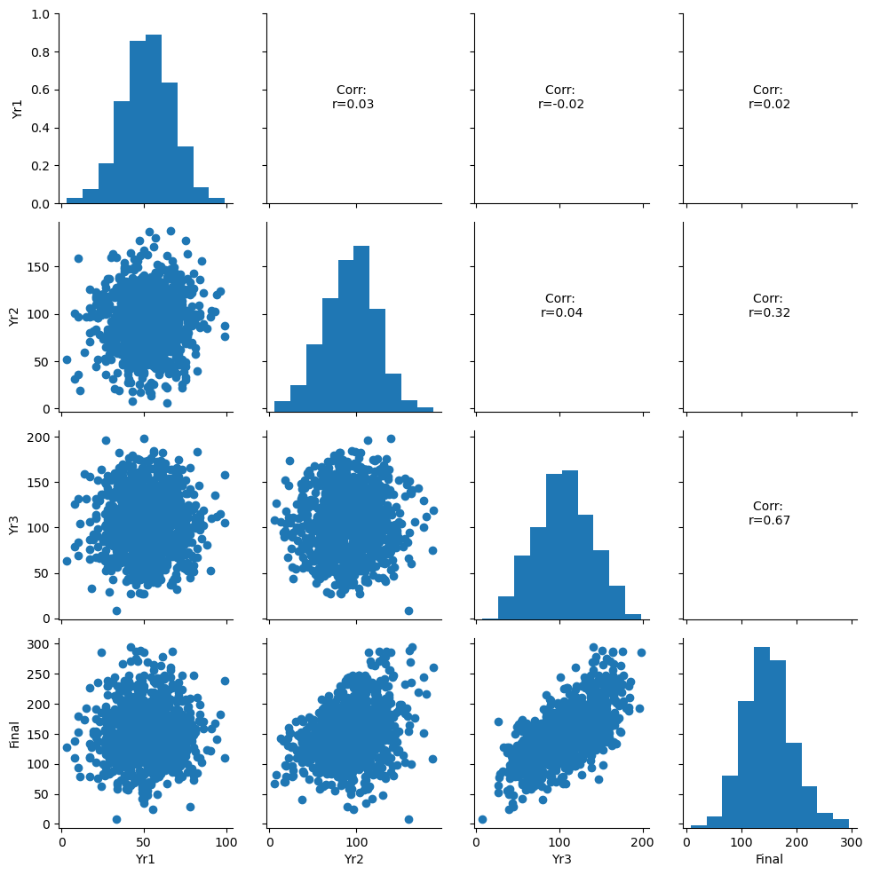

```python
%matplotlib inline
g = sns.PairGrid(ug)
g.map_diag(plt.hist)
g.map_lower(plt.scatter)

def disp_corr(x, y, **kwargs):
    ax = plt.gca()
    norm = plt.Normalize(-1,1)
    r = np.corrcoef(x,y)
    ax.annotate(f"Corr: \nr={r[0][1]:.2f}", xy=(.5,.5), xycoords='axes fraction', ha='center')

g.map_upper(disp_corr)

plt.show()
```

The pairplot above demonstrates a few things: the three predictors (yr1-3) appear to be normally distributed, as is the outcome variable (final). Next, Yr1 has poor correlation with all other factors, Yr2 has a moderate correlation to the outcome, and Yr3 has a strong correlation at .67. Lastly, the relationships that are present appear to be linear in nature.

This is important for the assumptions of the linear model, that it appears we have not violated assumptions of linearity, independence, or normality.

We can continue with running the linear regression model to run further diagnostics.

# Initial Model

```python
ug = sm.add_constant(ug, prepend=False)
y = ug['Final']
X = ug.drop(columns='Final')

mod = sm.OLS(y, X)
mod_fit = mod.fit()

mod_fit.summary()
```

OLS Regression Results

| Dep. Variable: | Final | R-squared: | 0.530 |
| --- | --- | --- | --- |
| Model: | OLS | Adj. R-squared: | 0.529 |
| Method: | Least Squares | F-statistic: | 365.5 |
| Date: | Thu, 12 Dec 2024 | Prob (F-statistic): | 8.22e-159 |
| Time: | 13:26:39 | Log-Likelihood: | -4711.6 |
| No. Observations: | 975 | AIC: | 9431. |
| Df Residuals: | 971 | BIC: | 9451. |
| Df Model: | 3 |  |  |
| Covariance Type: | nonrobust |  |  |

|  | coef | std err | t | P>\|t\| | [0.025 | 0.975] |
| --- | --- | --- | --- | --- | --- | --- |
| Yr1 | 0.0760 | 0.065 | 1.163 | 0.245 | -0.052 | 0.204 |
| Yr2 | 0.4313 | 0.033 | 13.267 | 0.000 | 0.367 | 0.495 |
| Yr3 | 0.8657 | 0.029 | 29.710 | 0.000 | 0.809 | 0.923 |
| const | 14.1460 | 5.480 | 2.581 | 0.010 | 3.392 | 24.900 |

| Omnibus: | 0.762 | Durbin-Watson: | 2.006 |
| --- | --- | --- | --- |
| Prob(Omnibus): | 0.683 | Jarque-Bera (JB): | 0.795 |
| Skew: | 0.067 | Prob(JB): | 0.672 |
| Kurtosis: | 2.961 | Cond. No. | 858. |

Notes:  
[1] Standard Errors assume that the covariance matrix of the errors is correctly specified.

# Diagnostics

## Residuals vs Fitted

The first diagnostic is the *Residuals vs. Fitted* graph, which visualizes how residuals (difference between predicted and actual values) vary across the fitted values (predicted values). This helps us to verify the assumptions of homoscedasticity (variance is the same for all variables), linearity, and normality.

With this graph we are looking for a random distribution of points in the scatterplot with no apparent funelling or clear patterns.

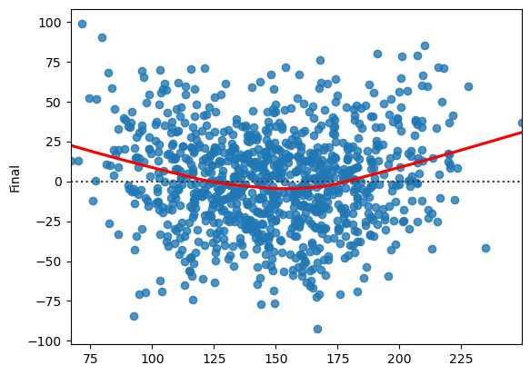

```python
%matplotlib inline
fitted = mod_fit.fittedvalues

sns.residplot(
    y=y,
    x=fitted,
    lowess=True,
    line_kws={'color':'red'}
)

plt.show()
```

It looks like there is a small funneling pattern but this is not large or clear enough to be of concern, mostly drawn up by the values at the far ends. We can further test this using a Breusch-Pagan test.

The null hypothesis for the Breusch-Pagan test is that data is homoscedastic, a significant result would indicate inequal variance for predicted values and residuals.

```python
breusch_pagan = bptest(resid = mod_fit.resid, exog_het = mod_fit.model.exog)
print(f'Breusch-Pagan test for homoscedasticity\n','-'*30, f'\nStatistic: {breusch_pagan[0]:.2f}\np-value: {breusch_pagan[1]:.2f} \nf-value: {breusch_pagan[2]:.2f} \nf p-value: {breusch_pagan[3]:.2f} ')
```

```
Breusch-Pagan test for homoscedasticity
 ------------------------------
Statistic: 4.02
p-value: 0.26
f-value: 1.34
f p-value: 0.26
```

## Normal Q-Q

This plot compares the distribution of residuals against a theoretical distribution (in this case, the normal distribution, as we are interested in seeing whether residuals are normally distributed). Visually, this would mean the plot of normalized residuals follows a 45 degree line, or there are no apparent deviations from a straight line.

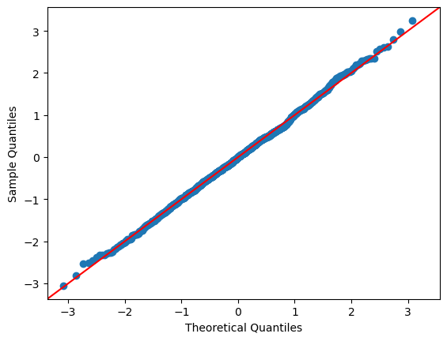

```python
%matplotlib inline
pplot = ProbPlot(
    mod_fit.get_influence().resid_studentized_internal
)
fig = pplot.qqplot(line='45')

plt.show()
```

The Q-Q plot above shows good evidence for normal distribution of residuals.

## Scale-Location

This is another method to support assumptions of homoscedasticity, linearity, and normality in conjunction with the Residuals vs. Fitted graph. These graphs generally present similar information, but the Scale-Location graph is useful when points are unevenly distributed across the x-axis.

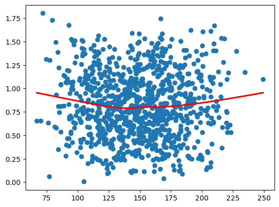

```python
abs_sqrt_norm_resid = abs((mod_fit.get_influence().resid_studentized_internal))**(1/2)

plt.scatter(fitted, abs_sqrt_norm_resid)
sns.regplot(
    x=fitted,
    y=abs_sqrt_norm_resid,
    scatter=False,
    ci=False,
    lowess=True,
    line_kws={'color': 'red'}
)

plt.show()
```

Once again, we see a slight curve but have shown already that there is not sufficient evidence for heteroscedasticity.

## Residuals vs. Leverage

This plot shows changes in all estimates when high-leverage values are removed, utilizing Cook's distance (represented by the dashed lines). Any points that fall outside of Cook's distance are considered "influential", meaning their removal would significantly impact the results of the model. Points further along the x-axis have greater leverage, or model influence. Points with greater absolute standardized residuals tend to indicate poor fits.

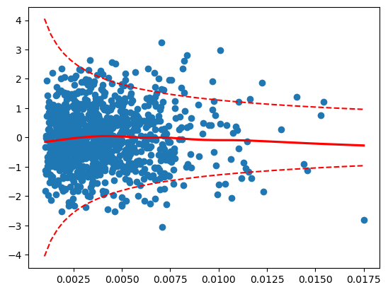

```python
leverage = mod_fit.get_influence().hat_matrix_diag
cooks_d = mod_fit.get_influence().cooks_distance[0]
norm_resid = mod_fit.get_influence().resid_studentized_internal
nparam = len(mod_fit.params)
nresid = len(mod_fit.resid)

plt.scatter(leverage, norm_resid)
sns.regplot(
    x=leverage,
    y=norm_resid,
    scatter=False,
    ci=False,
    lowess=True,
    line_kws={'color': 'red'}
)
factors = [4/nresid]

def cooks_distance_line(factor):
    p = nparam
    f = lambda x: np.sqrt((factor * p * ( 1-x)) / x)
    x = np.linspace(.001, max(leverage), 50)
    y = f(x)
    return x, y

for i , factor in enumerate(factors):
    xt, yt = cooks_distance_line(factor)
    plt.plot(xt, yt, ls = '--', color='red')
    plt.plot(xt, np.negative(yt), ls='--', color='red')


plt.show()
```

In our plot, we notice a number of high leverage points falling beyond Cook's distance, indicating problematic levels of influence. Furthermore, many of the points are poorly fit by the existing model, as evidenced by the high absolute-value normalized residuals. We are already aware that the model is a pretty poor fit given the low $R^2$ value, this provides further evidence for the point.

## VIF

Lastly, we can check for multicollinearity using the Variance Inflation Factor which examines correlation among 3 or more factors. General rules when interpreting are:

- VIF > 5: High Collinearity
- VIF < 1: Little to No Collinearity

```python
pred = X.drop(columns='const')
pd.Series(
    [vif(pred.values, i) for i in range(pred.shape[1])],
    index=pred.columns
)
```

```
Yr1    8.173631
Yr2    7.813291
Yr3    7.610574
dtype: float64
```

Given the high ( > 5) VIF scores, there is evidence for strong multicollinearity.

# Final Model

To recap what we have seen so far, our data does not violate assumptions of normality or homogeneity of variance. Though the predictors have low correlation values among each other, there is strong evidence for multicollinearity using the VIF score. Lastly, the Year 1 score is likely removable from the the model because it is a poor predictor.

Using the above information, a new model can be constructed and tested for accuracy. Our new model will:

- Drop Yr1 for low correlation to the outcome
- Model the interaction between the remaining predictors (Yr2 moderating Yr3)

```python
X2 = X.drop(columns='Yr1')
X2y = X2.join(y)

mod2 = smf.ols(formula='Final ~ Yr2 + Yr3 + Yr2 * Yr3', data=X2y)

res2 = mod2.fit()

res2.summary()
```

OLS Regression Results

| Dep. Variable: | Final | R-squared: | 0.592 |
| --- | --- | --- | --- |
| Model: | OLS | Adj. R-squared: | 0.590 |
| Method: | Least Squares | F-statistic: | 468.9 |
| Date: | Thu, 12 Dec 2024 | Prob (F-statistic): | 2.91e-188 |
| Time: | 13:26:39 | Log-Likelihood: | -4643.5 |
| No. Observations: | 975 | AIC: | 9295. |
| Df Residuals: | 971 | BIC: | 9315. |
| Df Model: | 3 |  |  |
| Covariance Type: | nonrobust |  |  |

|  | coef | std err | t | P>\|t\| | [0.025 | 0.975] |
| --- | --- | --- | --- | --- | --- | --- |
| Intercept | 131.9558 | 10.207 | 12.928 | 0.000 | 111.925 | 151.987 |
| Yr2 | -0.7947 | 0.106 | -7.528 | 0.000 | -1.002 | -0.588 |
| Yr3 | -0.2267 | 0.094 | -2.412 | 0.016 | -0.411 | -0.042 |
| Yr2:Yr3 | 0.0117 | 0.001 | 12.134 | 0.000 | 0.010 | 0.014 |

| Omnibus: | 0.692 | Durbin-Watson: | 2.011 |
| --- | --- | --- | --- |
| Prob(Omnibus): | 0.708 | Jarque-Bera (JB): | 0.764 |
| Skew: | -0.004 | Prob(JB): | 0.682 |
| Kurtosis: | 2.863 | Cond. No. | 1.21e+05 |

Notes:  
[1] Standard Errors assume that the covariance matrix of the errors is correctly specified.  
[2] The condition number is large, 1.21e+05. This might indicate that there are  
strong multicollinearity or other numerical problems.

The model accuracy based on $R^2$ has improved with the addition of the interaction term `Yr2:Yr3`, from $R^2=.53$ to $R^2=.59$. This interaction term is also statistically significant $t=12.13$, $p < .05$, which we might understand to mean that improvement (or worsening) from Year 2 to Year 3 is a strong predictor for final performance in addition to Year 2 and 3 performance.